# 3-2-1 checks

Ali Campbell

27/02/2023

**Run date and time: 2023-03-09 14:11:37**

## Introduction

- 3-2-1 data comes in two large tables that need to be formatted down and have a death rate per 1000 live births calculated
- This file runs some basic checks on the csv output and highlights some specific things that should manually be checked.

## Configurations

The configurations are:

- filepath for the input data: **D:/coding_repos/sdg_data_updates/3-2-1_new/Example_Input/EXAMPLE_cim2020deathcohortworkbook.xlsx**
- name of the tab the data are in; England & Wales: **Table_1**, UK: **Table_2**
- row number of the column names: E&W: **6**, UK: **6**
- location of the outputs: **Example_Output**

## Basic checks

- no duplicates present: **TRUE**

## Plots

Please check the plots below for any differences between the live data (which is pulled in from the sdg-data (platform) github repo) and the new data.

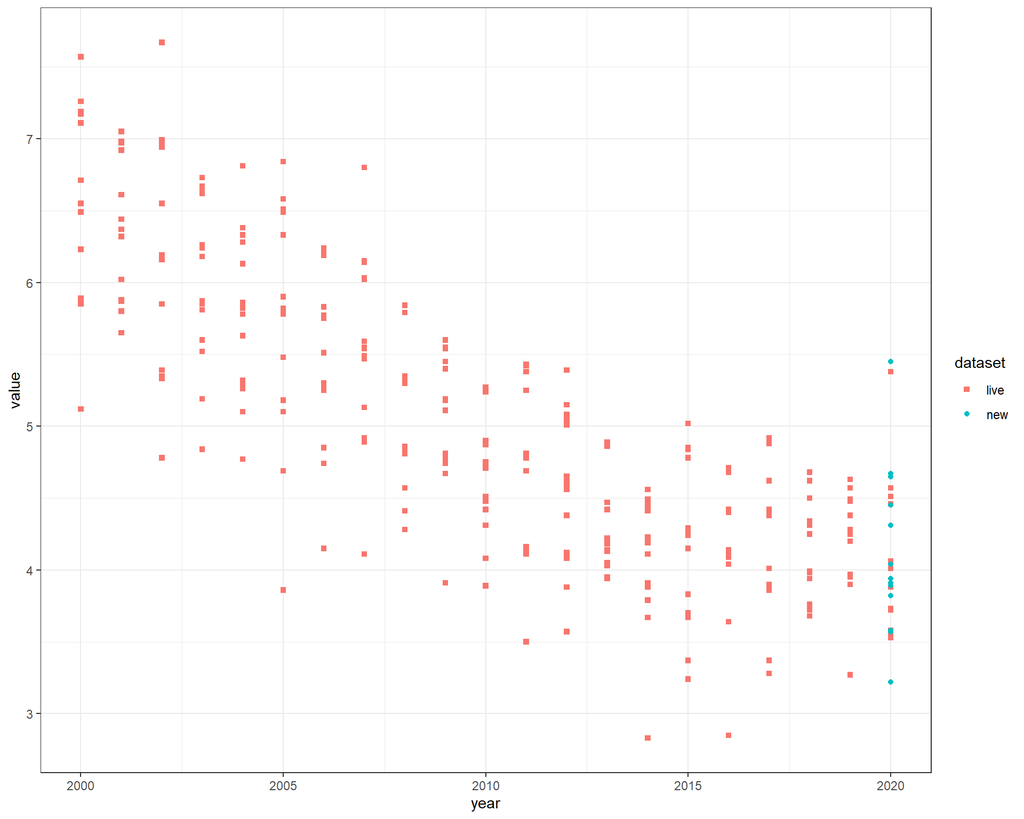

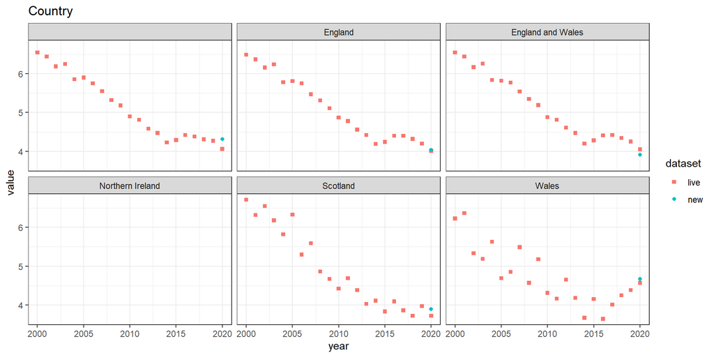

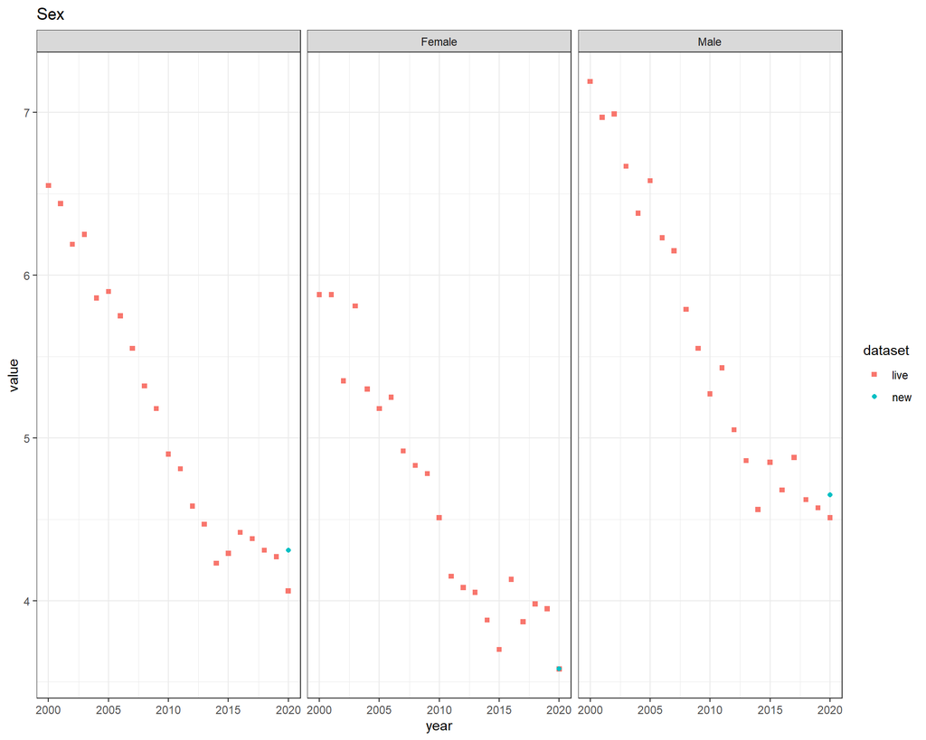

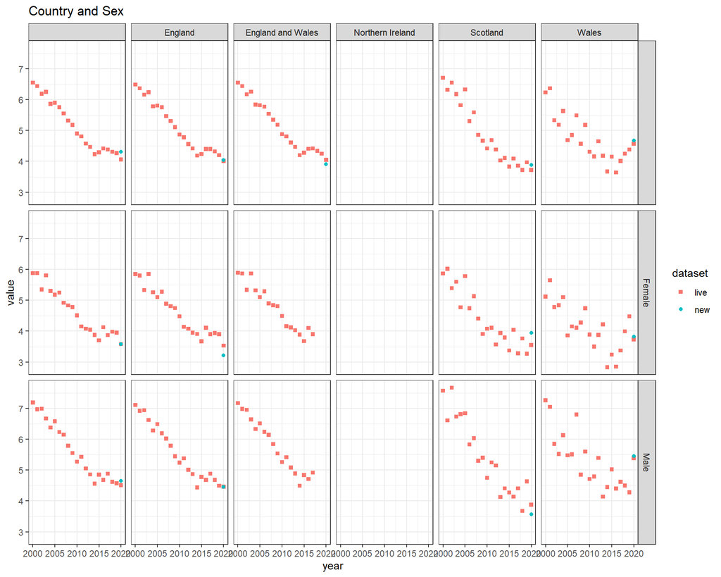

**If there are differences (see table below) please check that this still stands**

The table below shows all instances where the old value does not match the new value. It is sorted so the largest absolute differences appear first, but can be sorted in other ways using the arrows at the top.

| year | country | sex | live | new | difference |
| --- | --- | --- | --- | --- | --- |
| 2020 | Scotland | Female | 3.55 | 3.94 | 0.39 |
| 2020 | Scotland | Male | 3.88 | 3.57 | -0.31 |
| 2020 | England | Female | 3.53 | 3.22 | -0.31 |
| 2020 |  |  | 4.06 | 4.31 | 0.25 |
| 2020 | Scotland |  | 3.72 | 3.89 | 0.17 |
| 2020 |  | Male | 4.51 | 4.65 | 0.140000000000001 |
| 2020 | England and Wales |  | 4.05 | 3.91 | -0.14 |
| 2020 | Wales |  | 4.57 | 4.67 | 0.0999999999999996 |
| 2020 | Wales | Female | 3.73 | 3.82 | 0.0899999999999999 |
| 2020 | Wales | Male | 5.38 | 5.45 | 0.0700000000000003 |

[output cut: 2 more lines]

**R version 4.1.3 (2022-03-10)**

**Platform:** x86_64-w64-mingw32/x64 (64-bit)

**locale:** *LC_COLLATE=English_United Kingdom.1252*, *LC_CTYPE=English_United Kingdom.1252*, *LC_MONETARY=English_United Kingdom.1252*, *LC_NUMERIC=C* and *LC_TIME=English_United Kingdom.1252*

**attached base packages:** *stats*, *graphics*, *grDevices*, *utils*, *datasets*, *methods* and *base*

**other attached packages:** *pander(v.0.6.5)*, *DT(v.0.27)*, *ggplot2(v.3.4.1)*, *rmarkdown(v.2.20)*, *janitor(v.2.2.0)*, *readxl(v.1.4.2)*, *openxlsx(v.4.2.5.2)*, *rsdmx(v.0.6-2)*, *dplyr(v.1.1.0)*, *tidyr(v.1.3.0)*, *tidyxl(v.1.0.8)*, *unpivotr(v.0.6.3)*, *stringr(v.1.5.0)*, *SDGupdater(v.0.0.0.9000)* and *haven(v.2.5.2)*